[Edit on GitHub](https://github.com/DanielVandH/DelaunayTriangulation.jl/tree/main/docs/src/literate_tutorials/refinement.jl)

# Mesh Refinement

In this tutorial, we show how we can use mesh refinement to include the quality of a mesh by inserting more points. In this package, we allow for constant area and angle constraints, and also for custom constraints based on a user-provided function. You can also limit the maximum number of points. Moreover, any type of triangulation can be provided, regardless of whether the triangulation is unconstrained or triangulations, and regardless of the number of holes and domains.

Let us start by loading in the packages we will need.

```julia
using DelaunayTriangulation
using CairoMakie
using StableRNGs
```

## Unconstrained triangulation

Let us start with a simple example, refining an unconstrained triangulation. We will constrain the triangulation such that the minimum angle is 30 degrees, and the maximum area of a triangulation is 1% of the triangulation's total area. Note that below we need to make sure `points` is mutable, else it is not possible to push points into the triangulation. Here we use a tuple, but you could also use e.g. an `ElasticMatrix` from ElasticArrays.jl.

```julia
# Unconstrained triangulation
rng = StableRNG(123)
x = rand(rng, 50)
y = rand(rng, 50)
points = tuple.(x, y)
tri = triangulate(points; rng)
orig_tri = deepcopy(tri)
A = get_total_area(tri)
stats = refine!(tri; min_angle=30.0, max_area=0.01A, rng)
```

```
Delaunay Triangulation Statistics.
   Triangulation area: 0.6676219360027285
   Number of vertices: 343
   Number of solid vertices: 342
   Number of ghost vertices: 1
   Number of edges: 1023
   Number of solid edges: 949
   Number of ghost edges: 74
   Number of triangles: 608
   Number of solid triangles: 608
   Number of ghost triangles: 0
   Number of constrained boundary edges: 0
   Number of constrained interior edges: 0
   Number of constrained edges: 0
   Number of convex hull points: 74
   Smallest angle: 30.024063897404158°
   Largest angle: 119.95187220519168°
   Smallest area: 1.4366299754771527e-5
   Largest area: 0.006404471750712298
   Smallest radius-edge ratio: 0.5774192401879206
   Largest radius-edge ratio: 0.999273165528029
```

The `refine!` function operators on `tri` in-place, but the returned value is a `TriangulationStatistics` object that gives various statistics about the triangulation. As we can see, the maximum area of a triangle is about 0.0064, which is indeed less than 1% of the triangulation's area, which is about 0.0067. Moreover, the smallest angle is indeed greater than 30.

Let us compare the triangulation pre- and post-refinement.

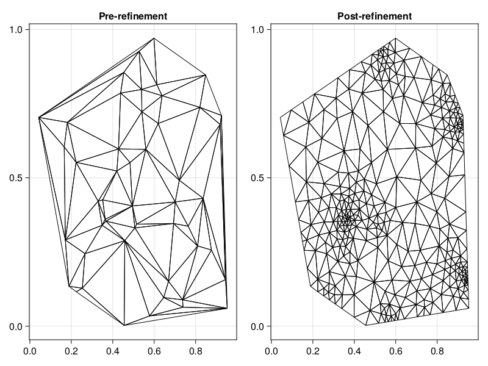

```julia
fig, ax, sc = triplot(orig_tri, axis=(title="Pre-refinement",))
ax = Axis(fig[1, 2], title="Post-refinement")
triplot!(ax, tri)
fig
```

The triangulation is now much finer. There are still some parts with many more triangles than other regions, but this is most nearly a boundary or where was a cluster of random points. If we wanted, we could refine again to try and improve this.

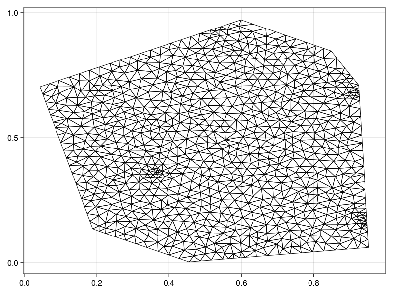

```julia
refine!(tri; min_angle=30.0, max_area=0.001A, rng) # 0.1% instead of 1%
fig, ax, sc = triplot(tri)
fig
```

The quality has now been improved. We could also try improving the minimum angle further, but even 30 is a bit closer to the limit of convergence (which is about 33.9 degrees). For example, if we try a minimum angle of 35 degrees, the algorithm just doesn't even converge, instead it reaches the maximum number of iterations, which is 100,000 by default.

```julia
test_tri = deepcopy(tri)
stats = refine!(test_tri; min_angle=35.0, max_area=0.001A, maxiters=5000, rng)
```

```
Delaunay Triangulation Statistics.
   Triangulation area: 0.6676219360027277
   Number of vertices: 5905
   Number of solid vertices: 5904
   Number of ghost vertices: 1
   Number of edges: 17709
   Number of solid edges: 17545
   Number of ghost edges: 164
   Number of triangles: 11642
   Number of solid triangles: 11642
   Number of ghost triangles: 0
   Number of constrained boundary edges: 0
   Number of constrained interior edges: 0
   Number of constrained edges: 0
   Number of convex hull points: 164
   Smallest angle: 26.00591276068488°
   Largest angle: 112.7934663219181°
   Smallest area: 4.856073018425794e-6
   Largest area: 0.0006434388833314077
   Smallest radius-edge ratio: 0.5773506989861914
   Largest radius-edge ratio: 1.140344742016754
```

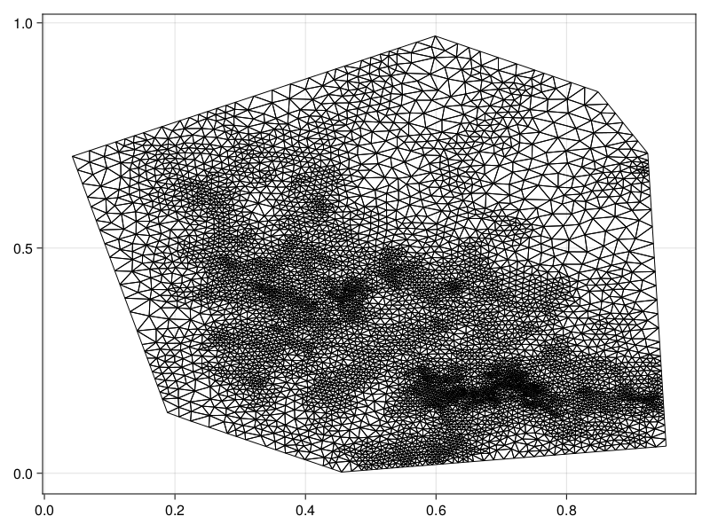

```julia
fig, ax, sc = triplot(test_tri)
fig
```

This is certainly not a suitable triangulation to use.

One useful figure to look at for these plots are histograms that look at the areas and angles. Looking to `tri`, we can plot these as follows:

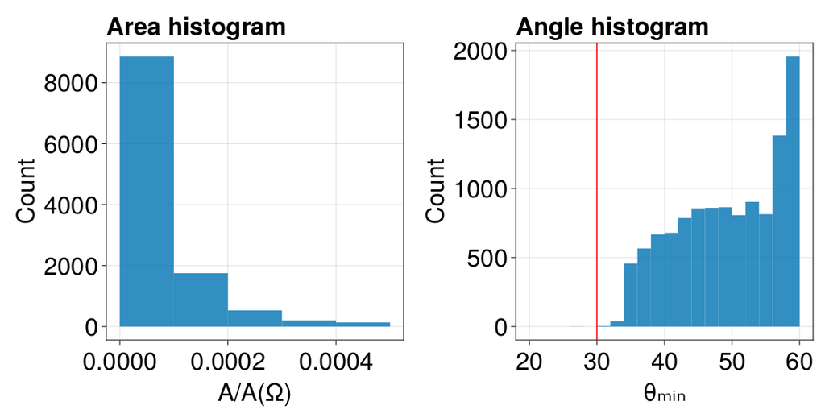

```julia
fig = Figure(fontsize=33)
areas = get_all_stat(stats, :area) ./ A
angles = first.(get_all_stat(stats, :angles)) # the first is the smallest
ax = Axis(fig[1, 1], xlabel="A/A(Ω)", ylabel="Count", title="Area histogram", width=400, height=400, titlealign=:left)
hist!(ax, areas, bins=0:0.0001:0.0005)
ax = Axis(fig[1, 2], xlabel="θₘᵢₙ", ylabel="Count", title="Angle histogram", width=400, height=400, titlealign=:left)
hist!(ax, rad2deg.(angles), bins=20:2:60)
vlines!(ax, [30.0], color=:red)
resize_to_layout!(fig)
fig
```

## Constrained triangulation and custom constraints

We now give an example of a constrained triangulation being refined. This is the most common case where the mesh refinement is needed. For this example, we consider an example with holes, but note that any triangulation can be refined, regardless of the type. Here is the triangulation we consider.

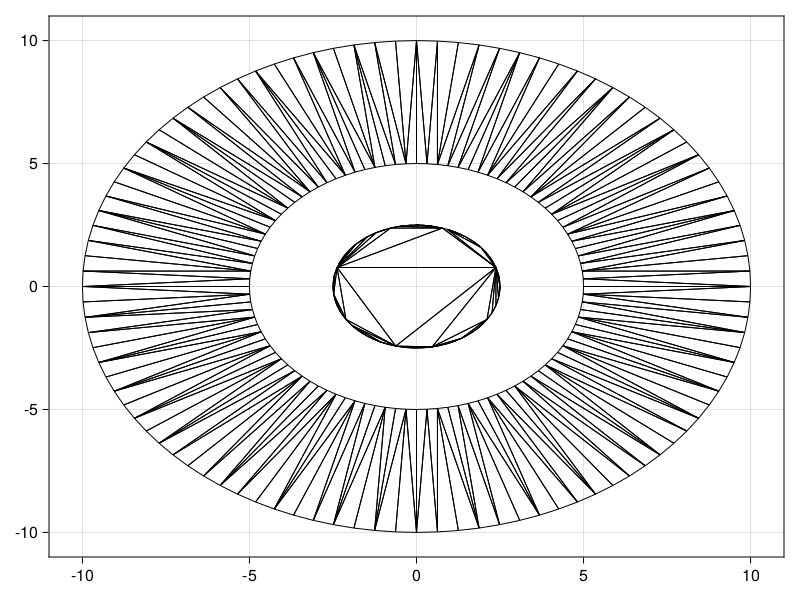

```julia
# Constrained triangulation and custom constraints
n = 100
θ = LinRange(0, 2π, n + 1)
θ = [θ[1:n]; 0]
rev_θ = reverse(θ) # to go from ccw to cw
r₁ = 10.0
r₂ = 5.0
r₃ = 2.5
outer_x, outer_y = r₁ * cos.(θ), r₁ * sin.(θ)
inner_x, inner_y = r₂ * cos.(rev_θ), r₂ * sin.(rev_θ)
innermost_x, innermost_y = r₃ * cos.(θ), r₃ * sin.(θ)
x = [[outer_x], [inner_x], [innermost_x]]
y = [[outer_y], [inner_y], [innermost_y]]
boundary_nodes, points = convert_boundary_points_to_indices(x, y)
rng = StableRNG(456)
tri = triangulate(points; boundary_nodes, rng, check_arguments = false)
fig, ax, sc = triplot(tri)
fig
```

Let us now refine this triangulation.

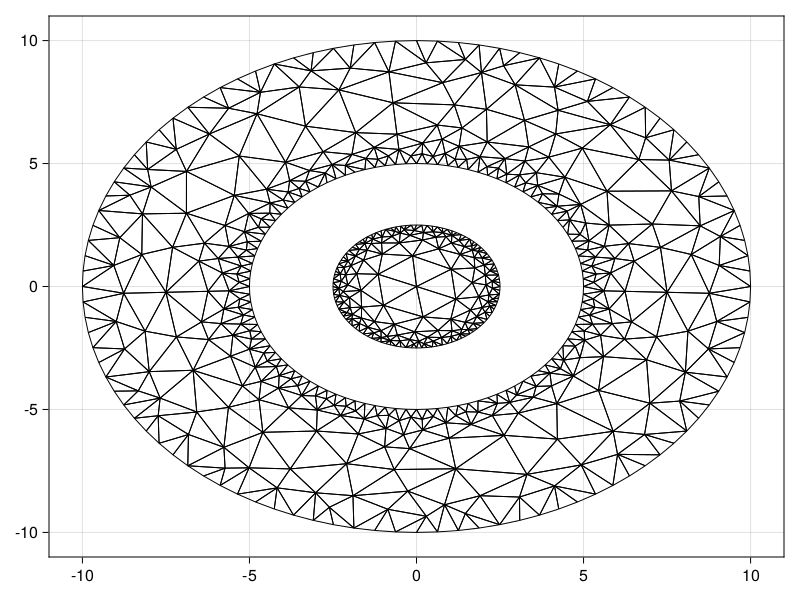

```julia
A = get_total_area(tri)
stats = refine!(tri; min_angle=27.3, max_area=0.01A, rng)
fig, ax, sc = triplot(tri)
fig
```

We inspect the plot, and we might think that it's perhaps not fine enough. Let's use finer constraints and see what happens. Since `refine!` operators on `tri` in-place, refining it again with the constraints below is going to take roughly the same amount of time as if we had refined it with these constraints in the first place.

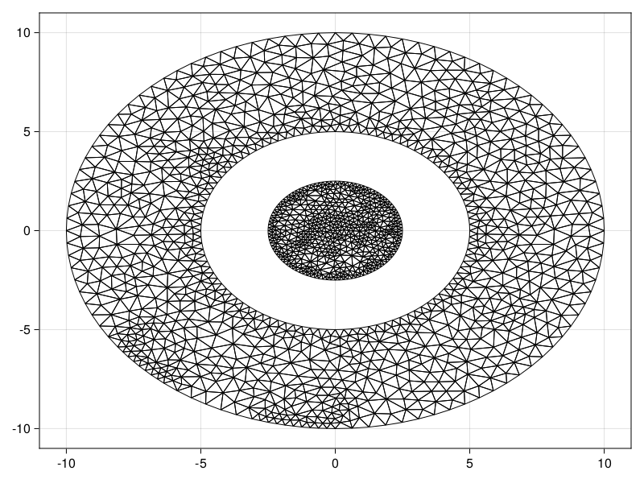

```julia
stats = refine!(tri; min_angle=33.9, max_area=0.001A, rng)
fig, ax, sc = triplot(tri)
fig
```

This is indeed much better, but notice that the inner hole is much more fine than the outer. This is because we are applying the same area constraint inside and outside, when really we should try and take note of the total contribution to the area that each part of the domain gives. To refine with this in mind, we need to use custom constraints. The function that we use for constraining the area takes the form `f(T, p, q, r, A)`, where `T` is the triangle's indices, `(p, q, r)` are its coordinates, and `A` is the area. It should return `true` if the triangle should be refined, and `false` otherwise. Let us define a function such that, instead of applying constraints so that the triangles are limited to 1% of the total triangulation area, we do 0.5% or 0.1% of the area of the inner or outer domain, respectively.

```julia
outer_area = π * (r₁^2 - r₂^2)
inner_area = π * r₃^2
function in_inner(p, q, r)
    px, py = getxy(p)
    qx, qy = getxy(q)
    rx, ry = getxy(r)
    cx, cy = (px + qx + rx) / 3, (py + qy + ry) / 3
    rad2 = cx^2 + cy^2
    return rad2 ≤ r₃^2
end
function area_constraint(T, p, q, r, A)
    ininner = in_inner(p, q, r)
    flag = if ininner
        A ≥ 0.005inner_area
    else
        A ≥ 0.001outer_area
    end
    return flag
end
```

```
area_constraint (generic function with 1 method)
```

Let's now refine. We recompute the triangulation so that we can see the new results.

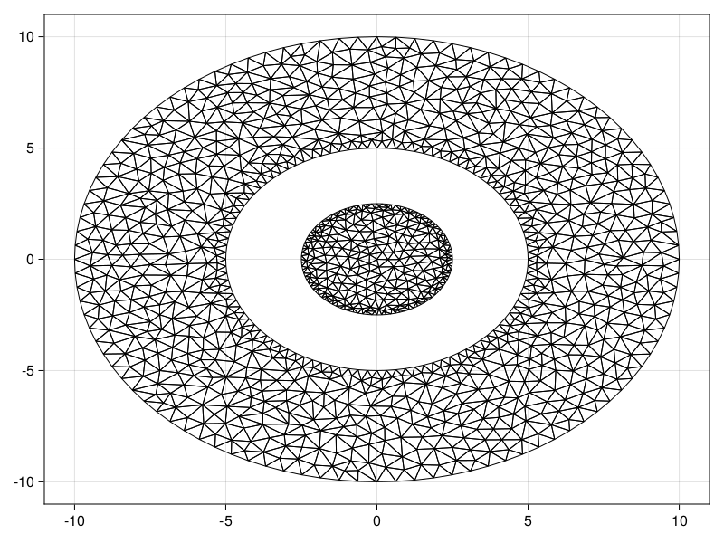

```julia
boundary_nodes, points = convert_boundary_points_to_indices(x, y)
rng = StableRNG(456)
tri = triangulate(points; boundary_nodes, rng, check_arguments = false)
stats = refine!(tri; min_angle=30.0, max_area=area_constraint, rng)
fig, ax, sc = triplot(tri)
fig
```

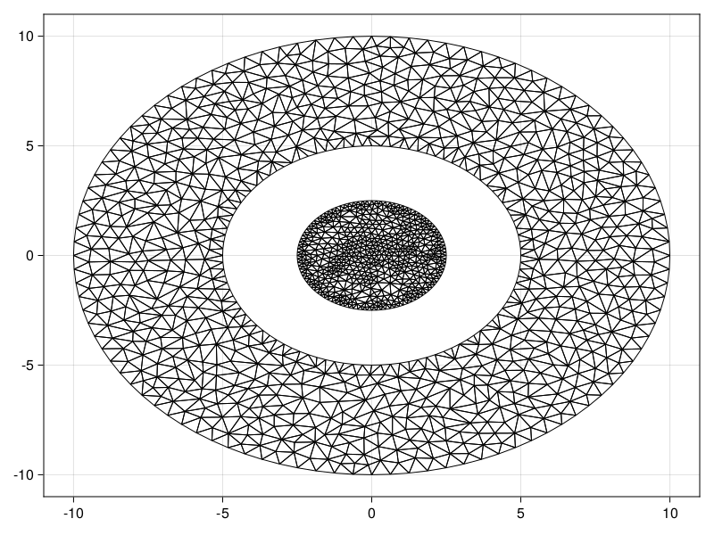

```julia
function angle_constraint(T, p, q, r, ρ)
    θ = asind(inv(2ρ))
    ininner = in_inner(p, q, r)
    flag = if ininner
        θ ≤ 33.9
    else
        θ ≤ 20.0
    end
    return flag
end
boundary_nodes, points = convert_boundary_points_to_indices(x, y)
rng = StableRNG(456)
tri = triangulate(points; boundary_nodes, rng, check_arguments = false)
stats = refine!(tri; max_radius_edge_ratio=angle_constraint, max_area=area_constraint, rng)
fig, ax, sc = triplot(tri)
fig
```

Indeed, the inner domain is much finer. These examples could be extended to more complicated cases, for example using adaptive mesh refinement for a numerical PDE solution so that triangles are refined based on some *a posteriori* error estimate, implemented using a custom area constraint like above, or even some refinement based on the triangle's location in space in case of some geospatial application.

## Domains with small angles

In the examples considered, none of the boundaries had small angles. When domains have small angles, it is not always possible to satisfy the minimum angle constraints, but the algorithm will still try its best to refine in these locations. Let's consider a complicated example with many small angles. We consider the boundary of Switzerland, as obtained in this [NaturalNeighbours.jl example](https://danielvandh.github.io/NaturalNeighbours.jl/stable/swiss/).

```julia
# Domains with small angles
using Downloads
using DelimitedFiles
boundary_url = "https://gist.githubusercontent.com/DanielVandH/13687b0918e45a416a5c93cd52c91449/raw/a8da6cdc94859fd66bcff85a2307f0f9cd57a18c/boundary.txt"
boundary_dir = Downloads.download(boundary_url)
boundary = readdlm(boundary_dir, skipstart=6)
boundary_points = [(boundary[i, 1], boundary[i, 2]) for i in axes(boundary, 1)]
reverse!(boundary_points)
```

```
5126-element Vector{Tuple{Float64, Float64}}:
 (7.133862520764, 45.871870678164)
 (7.138563027059, 45.871870678164)
 (7.138563027059, 45.876571184459)
 (7.143263533355, 45.876571184459)
 (7.14796403965, 45.876571184459)
 (7.152664545945, 45.876571184459)
 (7.15736505224, 45.876571184459)
 (7.162065558535, 45.876571184459)
 (7.162065558535, 45.871870678164)
 (7.166766064831, 45.871870678164)
 ⋮
 (7.110359989288, 45.857769159278)
 (7.115060495583, 45.857769159278)
 (7.119761001878, 45.857769159278)
 (7.119761001878, 45.862469665573)
 (7.124461508174, 45.862469665573)
 (7.129162014469, 45.862469665573)
 (7.129162014469, 45.867170171868)
 (7.133862520764, 45.867170171868)
 (7.133862520764, 45.871870678164)
```

Here is the boundary.

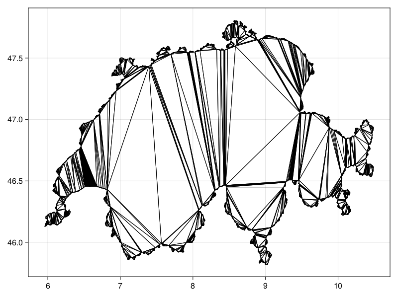

```julia
boundary_nodes, points = convert_boundary_points_to_indices(boundary_points)
rng = StableRNG(789)
tri = triangulate(points; boundary_nodes, rng)
fig, ax, sc = triplot(tri)
fig
```

Now let's refine.

```julia
A = get_total_area(tri)
refine!(tri; min_angle=30.0, max_area=0.001A, rng)
```

```
Delaunay Triangulation Statistics.
   Triangulation area: 4.865862585289831
   Number of vertices: 13541
   Number of solid vertices: 13540
   Number of ghost vertices: 1
   Number of edges: 40617
   Number of solid edges: 35492
   Number of ghost edges: 5125
   Number of triangles: 21953
   Number of solid triangles: 21953
   Number of ghost triangles: 0
   Number of constrained boundary edges: 5125
   Number of constrained interior edges: 0
   Number of constrained edges: 5125
   Number of convex hull points: 45
   Smallest angle: 6.763203204476883e-9°
   Largest angle: 135.00000000002166°
   Smallest area: 2.0828293316808154e-15
   Largest area: 0.0048575989965691626
   Smallest radius-edge ratio: 0.5774031823982464
   Largest radius-edge ratio: 4.235846371964363e9
```

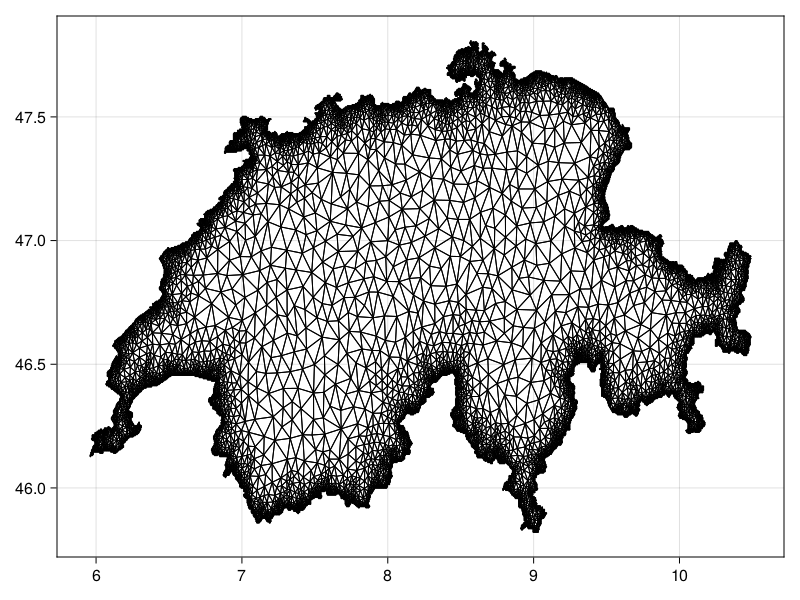

```julia
fig, ax, sc = triplot(tri)
fig
```

We see that the triangulation is now adequately refined. There are still triangles near the boundaries whose minimum angle is less than 30 degrees, though, because of the angles that boundary edges meet at in some places. Most of the triangles will satisfy the constraint, though, as we show below.

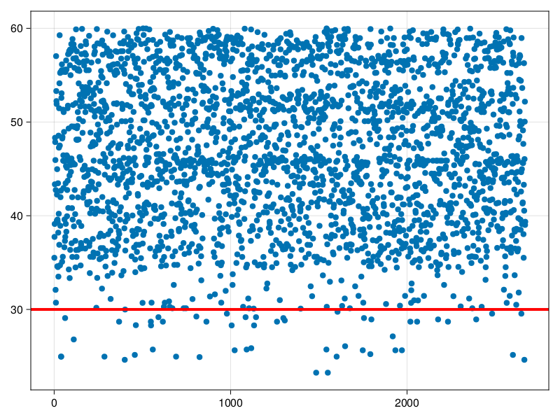

```julia
angles = first.(get_all_stat(stats, :angles)) # the first is the smallest
fig, ax, sc = scatter(rad2deg.(angles))
hlines!(ax, [30.0], color = :red, linewidth = 4)
fig
```

As we can see, the vast majority of the triangles satisfy the constraint, but there are still some that do not. Here is another set of results with a lower minimum angle constraint.

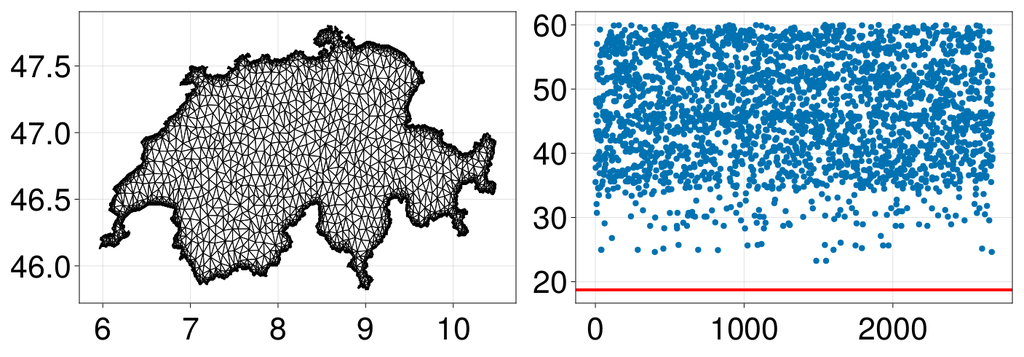

```julia
boundary_nodes, points = convert_boundary_points_to_indices(boundary_points)
rng = StableRNG(789)
tri = triangulate(points; boundary_nodes, rng)
refine!(tri; min_angle=18.73, max_area=0.001A, rng)
fig = Figure(fontsize = 43)
ax = Axis(fig[1, 1], width = 600, height = 400)
triplot!(tri)
ax = Axis(fig[1, 2], width = 600, height = 400)
angles = first.(get_all_stat(stats, :angles)) # the first is the smallest
scatter!(ax, rad2deg.(angles))
hlines!(ax, [18.73], color = :red, linewidth = 4)
resize_to_layout!(fig)
fig
```

In this case, all the triangles satisfy the constraint, of course at the expense of some other triangles having lesser quality.

## Just the code

An uncommented version of this example is given below. You can view the source code for this file [here](https://github.com/DanielVandH/DelaunayTriangulation.jl/tree/new-docs/docs/src/literate_tutorials/refinement.jl).

```julia
using DelaunayTriangulation
using CairoMakie
using StableRNGs

# Unconstrained triangulation
rng = StableRNG(123)
x = rand(rng, 50)
y = rand(rng, 50)
points = tuple.(x, y)
tri = triangulate(points; rng)
orig_tri = deepcopy(tri)
A = get_total_area(tri)
stats = refine!(tri; min_angle=30.0, max_area=0.01A, rng)

fig, ax, sc = triplot(orig_tri, axis=(title="Pre-refinement",))
ax = Axis(fig[1, 2], title="Post-refinement")
triplot!(ax, tri)
fig

refine!(tri; min_angle=30.0, max_area=0.001A, rng) # 0.1% instead of 1%
fig, ax, sc = triplot(tri)
fig

test_tri = deepcopy(tri)
stats = refine!(test_tri; min_angle=35.0, max_area=0.001A, maxiters=5000, rng)

fig, ax, sc = triplot(test_tri)
fig

fig = Figure(fontsize=33)
areas = get_all_stat(stats, :area) ./ A
angles = first.(get_all_stat(stats, :angles)) # the first is the smallest
ax = Axis(fig[1, 1], xlabel="A/A(Ω)", ylabel="Count", title="Area histogram", width=400, height=400, titlealign=:left)
hist!(ax, areas, bins=0:0.0001:0.0005)
ax = Axis(fig[1, 2], xlabel="θₘᵢₙ", ylabel="Count", title="Angle histogram", width=400, height=400, titlealign=:left)
hist!(ax, rad2deg.(angles), bins=20:2:60)
vlines!(ax, [30.0], color=:red)
resize_to_layout!(fig)
fig

# Constrained triangulation and custom constraints
n = 100
θ = LinRange(0, 2π, n + 1)
θ = [θ[1:n]; 0]
rev_θ = reverse(θ) # to go from ccw to cw
r₁ = 10.0
r₂ = 5.0
r₃ = 2.5
outer_x, outer_y = r₁ * cos.(θ), r₁ * sin.(θ)
inner_x, inner_y = r₂ * cos.(rev_θ), r₂ * sin.(rev_θ)
innermost_x, innermost_y = r₃ * cos.(θ), r₃ * sin.(θ)
x = [[outer_x], [inner_x], [innermost_x]]
y = [[outer_y], [inner_y], [innermost_y]]
boundary_nodes, points = convert_boundary_points_to_indices(x, y)
rng = StableRNG(456)
tri = triangulate(points; boundary_nodes, rng, check_arguments = false)
fig, ax, sc = triplot(tri)
fig

A = get_total_area(tri)
stats = refine!(tri; min_angle=27.3, max_area=0.01A, rng)
fig, ax, sc = triplot(tri)
fig

stats = refine!(tri; min_angle=33.9, max_area=0.001A, rng)
fig, ax, sc = triplot(tri)
fig

outer_area = π * (r₁^2 - r₂^2)
inner_area = π * r₃^2
function in_inner(p, q, r)
    px, py = getxy(p)
    qx, qy = getxy(q)
    rx, ry = getxy(r)
    cx, cy = (px + qx + rx) / 3, (py + qy + ry) / 3
    rad2 = cx^2 + cy^2
    return rad2 ≤ r₃^2
end
function area_constraint(T, p, q, r, A)
    ininner = in_inner(p, q, r)
    flag = if ininner
        A ≥ 0.005inner_area
    else
        A ≥ 0.001outer_area
    end
    return flag
end

boundary_nodes, points = convert_boundary_points_to_indices(x, y)
rng = StableRNG(456)
tri = triangulate(points; boundary_nodes, rng, check_arguments = false)
stats = refine!(tri; min_angle=30.0, max_area=area_constraint, rng)
fig, ax, sc = triplot(tri)
fig

function angle_constraint(T, p, q, r, ρ)
    θ = asind(inv(2ρ))
    ininner = in_inner(p, q, r)
    flag = if ininner
        θ ≤ 33.9
    else
        θ ≤ 20.0
    end
    return flag
end
boundary_nodes, points = convert_boundary_points_to_indices(x, y)
rng = StableRNG(456)
tri = triangulate(points; boundary_nodes, rng, check_arguments = false)
stats = refine!(tri; max_radius_edge_ratio=angle_constraint, max_area=area_constraint, rng)
fig, ax, sc = triplot(tri)
fig

# Domains with small angles
using Downloads
using DelimitedFiles
boundary_url = "https://gist.githubusercontent.com/DanielVandH/13687b0918e45a416a5c93cd52c91449/raw/a8da6cdc94859fd66bcff85a2307f0f9cd57a18c/boundary.txt"
boundary_dir = Downloads.download(boundary_url)
boundary = readdlm(boundary_dir, skipstart=6)
boundary_points = [(boundary[i, 1], boundary[i, 2]) for i in axes(boundary, 1)]
reverse!(boundary_points)

boundary_nodes, points = convert_boundary_points_to_indices(boundary_points)
rng = StableRNG(789)
tri = triangulate(points; boundary_nodes, rng)
fig, ax, sc = triplot(tri)
fig

A = get_total_area(tri)
refine!(tri; min_angle=30.0, max_area=0.001A, rng)

fig, ax, sc = triplot(tri)
fig

angles = first.(get_all_stat(stats, :angles)) # the first is the smallest
fig, ax, sc = scatter(rad2deg.(angles))
hlines!(ax, [30.0], color = :red, linewidth = 4)
fig

boundary_nodes, points = convert_boundary_points_to_indices(boundary_points)
rng = StableRNG(789)
tri = triangulate(points; boundary_nodes, rng)
refine!(tri; min_angle=18.73, max_area=0.001A, rng)
fig = Figure(fontsize = 43)
ax = Axis(fig[1, 1], width = 600, height = 400)
triplot!(tri)
ax = Axis(fig[1, 2], width = 600, height = 400)
angles = first.(get_all_stat(stats, :angles)) # the first is the smallest
scatter!(ax, rad2deg.(angles))
hlines!(ax, [18.73], color = :red, linewidth = 4)
resize_to_layout!(fig)
fig
```

*This page was generated using Literate.jl.*